# NODLab1

Ładowanie biblioteki Pandas

```python
import pandas as pd
```

Tworzenie ramki danych ze słownika

```python
dict_Citizen = {"Name" : ["Anna", "Piotr", "Katarzyna", "Marcin"],
            "Age" : [22,   33,  44, 55]}

df = pd.DataFrame(dict_Citizen)
df
```

|  | Name | Age |
| --- | --- | --- |
| 0 | Anna | 22 |
| 1 | Piotr | 33 |
| 2 | Katarzyna | 44 |
| 3 | Marcin | 55 |

Zachowanie ramki danych pobranych w pliku w formacie csv

```python
df.to_csv("citizen.csv")
```

Tworzenie ramki danych z listy list

```python
list_Citizen = [["Anna", "Piotr", "Katarzyna", "Marcin"],
            [22,   33,  44, 55]]

df = pd.DataFrame(list_Citizen)
df
```

|  | 0 | 1 | 2 | 3 |
| --- | --- | --- | --- | --- |
| 0 | Anna | Piotr | Katarzyna | Marcin |
| 1 | 22 | 33 | 44 | 55 |

Transponowanie (wymieniamy kolumny a wierszy)

```python
pd.DataFrame(list_Citizen).T
```

|  | 0 | 1 |
| --- | --- | --- |
| 0 | Anna | 22 |
| 1 | Piotr | 33 |
| 2 | Katarzyna | 44 |
| 3 | Marcin | 55 |

Tworzenie ramki danych z pliku

```python
df = pd.read_csv(r"/Users/annamazur/Desktop/studia/nod/laborki/Lab1/IHME_USA_RISK_SPENDING_2016_Y2020M09D29.CSV",

                 delimiter = ',', encoding = 'utf-8')
```

Wyświetlić pierwsze 10 wierszy ramki danych

```python
df.head(10)
```

|  | location_id | location_name | year | sex_id | sex | age_group_id | age_group_name | acause | cause_name | risk_id | risk_name | metric | mean | lower | upper |
| --- | --- | --- | --- | --- | --- | --- | --- | --- | --- | --- | --- | --- | --- | --- | --- |
| 0 | 102 | United States of America | 2016 | 1 | Male | 158 | <20 years | _all | All causes | 82 | Unsafe water, sanitation, and handwashing | 2016 US Dollar | 52.810750 | 34.776353 | 76.466271 |
| 1 | 102 | United States of America | 2016 | 1 | Male | 170 | 20 to 44 | _all | All causes | 82 | Unsafe water, sanitation, and handwashing | 2016 US Dollar | 48.000244 | 31.644490 | 70.893323 |
| 2 | 102 | United States of America | 2016 | 1 | Male | 171 | 45 to 64 | _all | All causes | 82 | Unsafe water, sanitation, and handwashing | 2016 US Dollar | 69.765933 | 45.764417 | 101.797946 |
| 3 | 102 | United States of America | 2016 | 1 | Male | 154 | 65 plus | _all | All causes | 82 | Unsafe water, sanitation, and handwashing | 2016 US Dollar | 88.960404 | 59.168652 | 128.091201 |
| 4 | 102 | United States of America | 2016 | 1 | Male | 22 | All Ages | _all | All causes | 82 | Unsafe water, sanitation, and handwashing | 2016 US Dollar | 259.537331 | 171.226033 | 375.015989 |
| 5 | 102 | United States of America | 2016 | 2 | Female | 158 | <20 years | _all | All causes | 82 | Unsafe water, sanitation, and handwashing | 2016 US Dollar | 50.183598 | 33.315353 | 74.363904 |
| 6 | 102 | United States of America | 2016 | 2 | Female | 170 | 20 to 44 | _all | All causes | 82 | Unsafe water, sanitation, and handwashing | 2016 US Dollar | 68.050031 | 44.128452 | 100.984476 |
| 7 | 102 | United States of America | 2016 | 2 | Female | 171 | 45 to 64 | _all | All causes | 82 | Unsafe water, sanitation, and handwashing | 2016 US Dollar | 101.383728 | 66.731697 | 150.924915 |
| 8 | 102 | United States of America | 2016 | 2 | Female | 154 | 65 plus | _all | All causes | 82 | Unsafe water, sanitation, and handwashing | 2016 US Dollar | 143.750803 | 94.584101 | 213.790479 |
| 9 | 102 | United States of America | 2016 | 2 | Female | 22 | All Ages | _all | All causes | 82 | Unsafe water, sanitation, and handwashing | 2016 US Dollar | 363.368161 | 240.982485 | 533.239066 |

Wyświetlić ostatnie 10 wierszy ramki danych

```python
df.tail(10)
```

|  | location_id | location_name | year | sex_id | sex | age_group_id | age_group_name | acause | cause_name | risk_id | risk_name | metric | mean | lower | upper |
| --- | --- | --- | --- | --- | --- | --- | --- | --- | --- | --- | --- | --- | --- | --- | --- |
| 1231 | 102 | United States of America | 2016 | 2 | Female | 158 | <20 years | rf | Expenditure on risk factors | 108 | High body-mass index | 2016 US Dollar | 101.248712 | 80.521641 | 126.900237 |
| 1232 | 102 | United States of America | 2016 | 2 | Female | 170 | 20 to 44 | rf | Expenditure on risk factors | 108 | High body-mass index | 2016 US Dollar | 2867.831645 | 2015.340713 | 3745.282634 |
| 1233 | 102 | United States of America | 2016 | 2 | Female | 171 | 45 to 64 | rf | Expenditure on risk factors | 108 | High body-mass index | 2016 US Dollar | 3036.836793 | 2104.770152 | 3961.429497 |
| 1234 | 102 | United States of America | 2016 | 2 | Female | 154 | 65 plus | rf | Expenditure on risk factors | 108 | High body-mass index | 2016 US Dollar | 1025.951678 | 697.331792 | 1909.052706 |
| 1235 | 102 | United States of America | 2016 | 2 | Female | 22 | All Ages | rf | Expenditure on risk factors | 108 | High body-mass index | 2016 US Dollar | 7031.868829 | 5216.248151 | 8948.681094 |
| 1236 | 102 | United States of America | 2016 | 3 | Both | 158 | <20 years | rf | Expenditure on risk factors | 108 | High body-mass index | 2016 US Dollar | 186.043387 | 142.143526 | 232.865620 |
| 1237 | 102 | United States of America | 2016 | 3 | Both | 170 | 20 to 44 | rf | Expenditure on risk factors | 108 | High body-mass index | 2016 US Dollar | 3697.662630 | 2626.047083 | 4824.208117 |
| 1238 | 102 | United States of America | 2016 | 3 | Both | 171 | 45 to 64 | rf | Expenditure on risk factors | 108 | High body-mass index | 2016 US Dollar | 4403.916422 | 3083.734761 | 5662.947080 |
| 1239 | 102 | United States of America | 2016 | 3 | Both | 154 | 65 plus | rf | Expenditure on risk factors | 108 | High body-mass index | 2016 US Dollar | 1457.018966 | 1104.520225 | 2292.252672 |
| 1240 | 102 | United States of America | 2016 | 3 | Both | 22 | All Ages | rf | Expenditure on risk factors | 108 | High body-mass index | 2016 US Dollar | 9744.641404 | 7222.418431 | 12418.772000 |

Wyświetlić informacje o ramce danych

```python
df.info()
```

```
<class 'pandas.DataFrame'>
RangeIndex: 1241 entries, 0 to 1240
Data columns (total 15 columns):
 #   Column          Non-Null Count  Dtype
---  ------          --------------  -----
 0   location_id     1241 non-null   int64
 1   location_name   1241 non-null   str
 2   year            1241 non-null   int64
 3   sex_id          1241 non-null   int64
 4   sex             1241 non-null   str
 5   age_group_id    1241 non-null   int64
 6   age_group_name  1241 non-null   str
 7   acause          1241 non-null   str
 8   cause_name      1241 non-null   str
 9   risk_id         1241 non-null   int64
 10  risk_name       1241 non-null   str
 11  metric          1241 non-null   str
 12  mean            1241 non-null   float64
 13  lower           1241 non-null   float64
 14  upper           1241 non-null   float64
dtypes: float64(3), int64(5), str(7)
memory usage: 145.6 KB
```

Wyświetlić ile wierszy i kolumn znajduje sie w ramce danych

```python
df.shape
```

```
(1241, 15)
```

```python
df.describe()
```

|  | location_id | year | sex_id | age_group_id | risk_id | mean | lower | upper |
| --- | --- | --- | --- | --- | --- | --- | --- | --- |
| count | 1241.0 | 1241.0 | 1241.000000 | 1241.000000 | 1241.000000 | 1241.000000 | 1241.000000 | 1241.000000 |
| mean | 102.0 | 2016.0 | 2.020145 | 132.887188 | 129.024174 | 7523.642696 | 5972.186569 | 9227.098980 |
| std | 0.0 | 0.0 | 0.812452 | 59.017044 | 73.481341 | 18443.451439 | 15681.094146 | 21316.739752 |
| min | 102.0 | 2016.0 | 1.000000 | 22.000000 | 82.000000 | 0.058442 | -4401.524592 | 0.105215 |
| 25% | 102.0 | 2016.0 | 1.000000 | 154.000000 | 98.000000 | 275.378150 | 129.072794 | 421.882542 |
| 50% | 102.0 | 2016.0 | 2.000000 | 158.000000 | 105.000000 | 1372.476758 | 821.243571 | 2097.737090 |
| 75% | 102.0 | 2016.0 | 3.000000 | 170.000000 | 125.000000 | 5763.893904 | 4033.397743 | 7515.218944 |
| max | 102.0 | 2016.0 | 3.000000 | 171.000000 | 381.000000 | 238503.405500 | 178217.189400 | 291573.753200 |

Wyświetlić informację statystyczną o kolumnach kategoryzowanych (ile unikalnych wartości, top - jaka jest najpopularniejsza wartość, freq - jak często najpopularniejsza)

```python
df.describe(include = 'str')
```

|  | location_name | sex | age_group_name | acause | cause_name | risk_name | metric |
| --- | --- | --- | --- | --- | --- | --- | --- |
| count | 1241 | 1241 | 1241 | 1241 | 1241 | 1241 | 1241 |
| unique | 1 | 3 | 5 | 13 | 13 | 19 | 1 |
| top | United States of America | Female | 20 to 44 | _all | All causes | Alcohol use | 2016 US Dollar |
| freq | 1241 | 422 | 271 | 268 | 268 | 150 | 1241 |

Usunąć brakujące wartości w ramce danych

```python
df.dropna(inplace=True)
```

Przedstawić wybór wierszy i kolumny używając nazw oraz indeksów na różne sposoby

```python
df["location_name"]
```

```
0       United States of America
1       United States of America
2       United States of America
3       United States of America
4       United States of America
                  ...
1236    United States of America
1237    United States of America
1238    United States of America
1239    United States of America
1240    United States of America
Name: location_name, Length: 1241, dtype: str
```

```python
df.location_name
```

```
0       United States of America
1       United States of America
2       United States of America
3       United States of America
4       United States of America
                  ...
1236    United States of America
1237    United States of America
1238    United States of America
1239    United States of America
1240    United States of America
Name: location_name, Length: 1241, dtype: str
```

```python
df[["location_name","sex","mean"]]
```

|  | location_name | sex | mean |
| --- | --- | --- | --- |
| 0 | United States of America | Male | 52.810750 |
| 1 | United States of America | Male | 48.000244 |
| 2 | United States of America | Male | 69.765933 |
| 3 | United States of America | Male | 88.960404 |
| 4 | United States of America | Male | 259.537331 |
| ... | ... | ... | ... |
| 1236 | United States of America | Both | 186.043387 |
| 1237 | United States of America | Both | 3697.662630 |
| 1238 | United States of America | Both | 4403.916422 |
| 1239 | United States of America | Both | 1457.018966 |
| 1240 | United States of America | Both | 9744.641404 |

1241 rows × 3 columns

```python
df.loc[:, "risk_name":"mean"]
```

|  | risk_name | metric | mean |
| --- | --- | --- | --- |
| 0 | Unsafe water, sanitation, and handwashing | 2016 US Dollar | 52.810750 |
| 1 | Unsafe water, sanitation, and handwashing | 2016 US Dollar | 48.000244 |
| 2 | Unsafe water, sanitation, and handwashing | 2016 US Dollar | 69.765933 |
| 3 | Unsafe water, sanitation, and handwashing | 2016 US Dollar | 88.960404 |
| 4 | Unsafe water, sanitation, and handwashing | 2016 US Dollar | 259.537331 |
| ... | ... | ... | ... |
| 1236 | High body-mass index | 2016 US Dollar | 186.043387 |
| 1237 | High body-mass index | 2016 US Dollar | 3697.662630 |
| 1238 | High body-mass index | 2016 US Dollar | 4403.916422 |
| 1239 | High body-mass index | 2016 US Dollar | 1457.018966 |
| 1240 | High body-mass index | 2016 US Dollar | 9744.641404 |

1241 rows × 3 columns

```python
df.loc[152:163, "risk_name":"mean"]
```

|  | risk_name | metric | mean |
| --- | --- | --- | --- |
| 152 | Low bone mineral density | 2016 US Dollar | 164.701276 |
| 153 | Low bone mineral density | 2016 US Dollar | 3682.323776 |
| 154 | Low bone mineral density | 2016 US Dollar | 16003.648570 |
| 155 | Low bone mineral density | 2016 US Dollar | 19850.673630 |
| 156 | Low bone mineral density | 2016 US Dollar | 294.611317 |
| 157 | Low bone mineral density | 2016 US Dollar | 5580.127929 |
| 158 | Low bone mineral density | 2016 US Dollar | 21347.928040 |
| 159 | Low bone mineral density | 2016 US Dollar | 27222.667280 |
| 160 | Dietary risks | 2016 US Dollar | 5500.698186 |
| 161 | Dietary risks | 2016 US Dollar | 39606.882580 |
| 162 | Dietary risks | 2016 US Dollar | 33933.362510 |
| 163 | Dietary risks | 2016 US Dollar | 79040.943270 |

```python
df.iloc[152:163, 3:8]
```

|  | sex_id | sex | age_group_id | age_group_name | acause |
| --- | --- | --- | --- | --- | --- |
| 152 | 2 | Female | 170 | 20 to 44 | _all |
| 153 | 2 | Female | 171 | 45 to 64 | _all |
| 154 | 2 | Female | 154 | 65 plus | _all |
| 155 | 2 | Female | 22 | All Ages | _all |
| 156 | 3 | Both | 170 | 20 to 44 | _all |
| 157 | 3 | Both | 171 | 45 to 64 | _all |
| 158 | 3 | Both | 154 | 65 plus | _all |
| 159 | 3 | Both | 22 | All Ages | _all |
| 160 | 1 | Male | 170 | 20 to 44 | _all |
| 161 | 1 | Male | 171 | 45 to 64 | _all |
| 162 | 1 | Male | 154 | 65 plus | _all |

Przedstawić wybór wierszy z ramki danych pod warunkiem odnośnie określonej wartości kolumny

```python
df[df["age_group_id"] == 22]
```

|  | location_id | location_name | year | sex_id | sex | age_group_id | age_group_name | acause | cause_name | risk_id | risk_name | metric | mean | lower | upper |
| --- | --- | --- | --- | --- | --- | --- | --- | --- | --- | --- | --- | --- | --- | --- | --- |
| 4 | 102 | United States of America | 2016 | 1 | Male | 22 | All Ages | _all | All causes | 82 | Unsafe water, sanitation, and handwashing | 2016 US Dollar | 259.537331 | 171.226033 | 375.015989 |
| 9 | 102 | United States of America | 2016 | 2 | Female | 22 | All Ages | _all | All causes | 82 | Unsafe water, sanitation, and handwashing | 2016 US Dollar | 363.368161 | 240.982485 | 533.239066 |
| 14 | 102 | United States of America | 2016 | 3 | Both | 22 | All Ages | _all | All causes | 82 | Unsafe water, sanitation, and handwashing | 2016 US Dollar | 622.905491 | 412.025513 | 904.227971 |
| 19 | 102 | United States of America | 2016 | 1 | Male | 22 | All Ages | _all | All causes | 85 | Air pollution | 2016 US Dollar | 16732.360820 | 10715.488990 | 23388.850460 |
| 24 | 102 | United States of America | 2016 | 2 | Female | 22 | All Ages | _all | All causes | 85 | Air pollution | 2016 US Dollar | 16866.903310 | 10267.186300 | 23763.720180 |
| ... | ... | ... | ... | ... | ... | ... | ... | ... | ... | ... | ... | ... | ... | ... | ... |
| 1220 | 102 | United States of America | 2016 | 2 | Female | 22 | All Ages | rf | Expenditure on risk factors | 107 | High systolic blood pressure | 2016 US Dollar | 41571.356740 | 37609.392360 | 48057.338180 |
| 1225 | 102 | United States of America | 2016 | 3 | Both | 22 | All Ages | rf | Expenditure on risk factors | 107 | High systolic blood pressure | 2016 US Dollar | 78978.208460 | 72635.368470 | 86818.864220 |
| 1230 | 102 | United States of America | 2016 | 1 | Male | 22 | All Ages | rf | Expenditure on risk factors | 108 | High body-mass index | 2016 US Dollar | 2712.772576 | 2026.699974 | 3398.799305 |
| 1235 | 102 | United States of America | 2016 | 2 | Female | 22 | All Ages | rf | Expenditure on risk factors | 108 | High body-mass index | 2016 US Dollar | 7031.868829 | 5216.248151 | 8948.681094 |
| 1240 | 102 | United States of America | 2016 | 3 | Both | 22 | All Ages | rf | Expenditure on risk factors | 108 | High body-mass index | 2016 US Dollar | 9744.641404 | 7222.418431 | 12418.772000 |

271 rows × 15 columns

Przedstawić wybór wierszy z ramki danych pod warunkiem spełnienia kilku warunków jednocześnie

```python
df[(df["age_group_id"] == 22) & (df["sex"] == "Both") & (df["mean"] <1000)]
```

|  | location_id | location_name | year | sex_id | sex | age_group_id | age_group_name | acause | cause_name | risk_id | risk_name | metric | mean | lower | upper |
| --- | --- | --- | --- | --- | --- | --- | --- | --- | --- | --- | --- | --- | --- | --- | --- |
| 14 | 102 | United States of America | 2016 | 3 | Both | 22 | All Ages | _all | All causes | 82 | Unsafe water, sanitation, and handwashing | 2016 US Dollar | 622.905491 | 412.025513 | 904.227971 |
| 282 | 102 | United States of America | 2016 | 3 | Both | 22 | All Ages | _comm | Communicable diseases | 82 | Unsafe water, sanitation, and handwashing | 2016 US Dollar | 622.905491 | 412.025513 | 904.227971 |
| 357 | 102 | United States of America | 2016 | 3 | Both | 22 | All Ages | _comm | Communicable diseases | 103 | Drug use | 2016 US Dollar | 710.214052 | 487.676182 | 1028.873142 |
| 369 | 102 | United States of America | 2016 | 3 | Both | 22 | All Ages | _comm | Communicable diseases | 105 | High fasting plasma glucose | 2016 US Dollar | 39.338524 | 23.915611 | 59.723610 |
| 379 | 102 | United States of America | 2016 | 3 | Both | 22 | All Ages | _comm | Communicable diseases | 135 | Intimate partner violence | 2016 US Dollar | 750.140375 | 394.123717 | 1231.661870 |
| 418 | 102 | United States of America | 2016 | 3 | Both | 22 | All Ages | _dube | Diabetes and urogenital, blood, and endocrine ... | 89 | Other environmental risks | 2016 US Dollar | 400.286224 | 166.531517 | 700.758259 |
| 445 | 102 | United States of America | 2016 | 3 | Both | 22 | All Ages | _dube | Diabetes and urogenital, blood, and endocrine ... | 102 | Alcohol use | 2016 US Dollar | 874.694995 | 552.846520 | 1145.084100 |
| 568 | 102 | United States of America | 2016 | 3 | Both | 22 | All Ages | _inj | Injuries | 103 | Drug use | 2016 US Dollar | 388.084369 | 217.344854 | 618.800811 |
| 620 | 102 | United States of America | 2016 | 3 | Both | 22 | All Ages | _mental | Mental and substance use disorders | 89 | Other environmental risks | 2016 US Dollar | 267.470467 | 131.150831 | 381.489610 |
| 687 | 102 | United States of America | 2016 | 3 | Both | 22 | All Ages | _neo | Neoplasms | 85 | Air pollution | 2016 US Dollar | 333.082444 | 138.672156 | 584.200261 |
| 702 | 102 | United States of America | 2016 | 3 | Both | 22 | All Ages | _neo | Neoplasms | 89 | Other environmental risks | 2016 US Dollar | 210.159416 | 95.547789 | 374.988661 |
| 744 | 102 | United States of America | 2016 | 3 | Both | 22 | All Ages | _neo | Neoplasms | 103 | Drug use | 2016 US Dollar | 578.941799 | 489.742369 | 693.981487 |
| 792 | 102 | United States of America | 2016 | 3 | Both | 22 | All Ages | _neo | Neoplasms | 125 | Low physical activity | 2016 US Dollar | 436.678150 | 91.629065 | 960.921161 |
| 817 | 102 | United States of America | 2016 | 3 | Both | 22 | All Ages | _neo | Neoplasms | 170 | Unsafe sex | 2016 US Dollar | 785.191668 | 630.709503 | 943.186593 |
| 1156 | 102 | United States of America | 2016 | 3 | Both | 22 | All Ages | msk | Musculoskeletal disorders | 341 | Impaired kidney function | 2016 US Dollar | 822.745152 | 358.591128 | 2403.048212 |

Wybrać wiersze które zawierają w kolumnie kategoryzowanej określone słowo

```python
df[df["cause_name"].str.contains("diseases")]
```

|  | location_id | location_name | year | sex_id | sex | age_group_id | age_group_name | acause | cause_name | risk_id | risk_name | metric | mean | lower | upper |
| --- | --- | --- | --- | --- | --- | --- | --- | --- | --- | --- | --- | --- | --- | --- | --- |
| 268 | 102 | United States of America | 2016 | 1 | Male | 158 | <20 years | _comm | Communicable diseases | 82 | Unsafe water, sanitation, and handwashing | 2016 US Dollar | 52.810750 | 34.776353 | 76.466271 |
| 269 | 102 | United States of America | 2016 | 1 | Male | 170 | 20 to 44 | _comm | Communicable diseases | 82 | Unsafe water, sanitation, and handwashing | 2016 US Dollar | 48.000244 | 31.644490 | 70.893323 |
| 270 | 102 | United States of America | 2016 | 1 | Male | 171 | 45 to 64 | _comm | Communicable diseases | 82 | Unsafe water, sanitation, and handwashing | 2016 US Dollar | 69.765933 | 45.764417 | 101.797946 |
| 271 | 102 | United States of America | 2016 | 1 | Male | 154 | 65 plus | _comm | Communicable diseases | 82 | Unsafe water, sanitation, and handwashing | 2016 US Dollar | 88.960404 | 59.168652 | 128.091201 |
| 272 | 102 | United States of America | 2016 | 1 | Male | 22 | All Ages | _comm | Communicable diseases | 82 | Unsafe water, sanitation, and handwashing | 2016 US Dollar | 259.537331 | 171.226033 | 375.015989 |
| ... | ... | ... | ... | ... | ... | ... | ... | ... | ... | ... | ... | ... | ... | ... | ... |
| 1206 | 102 | United States of America | 2016 | 3 | Both | 158 | <20 years | resp | Chronic respiratory diseases | 126 | Occupational risks | 2016 US Dollar | 61.464569 | 49.996517 | 75.317776 |
| 1207 | 102 | United States of America | 2016 | 3 | Both | 170 | 20 to 44 | resp | Chronic respiratory diseases | 126 | Occupational risks | 2016 US Dollar | 773.656004 | 649.979522 | 902.439159 |
| 1208 | 102 | United States of America | 2016 | 3 | Both | 171 | 45 to 64 | resp | Chronic respiratory diseases | 126 | Occupational risks | 2016 US Dollar | 1956.870521 | 1630.111685 | 2292.750220 |
| 1209 | 102 | United States of America | 2016 | 3 | Both | 154 | 65 plus | resp | Chronic respiratory diseases | 126 | Occupational risks | 2016 US Dollar | 1687.262878 | 1288.917391 | 2127.096398 |
| 1210 | 102 | United States of America | 2016 | 3 | Both | 22 | All Ages | resp | Chronic respiratory diseases | 126 | Occupational risks | 2016 US Dollar | 4479.253973 | 3846.770828 | 5176.065094 |

520 rows × 15 columns

Wybrać wiersze które nie zawierają w kolumnie kategoryzowanej określone słowo

```python
df[df["cause_name"].str.contains("diseases") == False]
```

|  | location_id | location_name | year | sex_id | sex | age_group_id | age_group_name | acause | cause_name | risk_id | risk_name | metric | mean | lower | upper |
| --- | --- | --- | --- | --- | --- | --- | --- | --- | --- | --- | --- | --- | --- | --- | --- |
| 0 | 102 | United States of America | 2016 | 1 | Male | 158 | <20 years | _all | All causes | 82 | Unsafe water, sanitation, and handwashing | 2016 US Dollar | 52.810750 | 34.776353 | 76.466271 |
| 1 | 102 | United States of America | 2016 | 1 | Male | 170 | 20 to 44 | _all | All causes | 82 | Unsafe water, sanitation, and handwashing | 2016 US Dollar | 48.000244 | 31.644490 | 70.893323 |
| 2 | 102 | United States of America | 2016 | 1 | Male | 171 | 45 to 64 | _all | All causes | 82 | Unsafe water, sanitation, and handwashing | 2016 US Dollar | 69.765933 | 45.764417 | 101.797946 |
| 3 | 102 | United States of America | 2016 | 1 | Male | 154 | 65 plus | _all | All causes | 82 | Unsafe water, sanitation, and handwashing | 2016 US Dollar | 88.960404 | 59.168652 | 128.091201 |
| 4 | 102 | United States of America | 2016 | 1 | Male | 22 | All Ages | _all | All causes | 82 | Unsafe water, sanitation, and handwashing | 2016 US Dollar | 259.537331 | 171.226033 | 375.015989 |
| ... | ... | ... | ... | ... | ... | ... | ... | ... | ... | ... | ... | ... | ... | ... | ... |
| 1236 | 102 | United States of America | 2016 | 3 | Both | 158 | <20 years | rf | Expenditure on risk factors | 108 | High body-mass index | 2016 US Dollar | 186.043387 | 142.143526 | 232.865620 |
| 1237 | 102 | United States of America | 2016 | 3 | Both | 170 | 20 to 44 | rf | Expenditure on risk factors | 108 | High body-mass index | 2016 US Dollar | 3697.662630 | 2626.047083 | 4824.208117 |
| 1238 | 102 | United States of America | 2016 | 3 | Both | 171 | 45 to 64 | rf | Expenditure on risk factors | 108 | High body-mass index | 2016 US Dollar | 4403.916422 | 3083.734761 | 5662.947080 |
| 1239 | 102 | United States of America | 2016 | 3 | Both | 154 | 65 plus | rf | Expenditure on risk factors | 108 | High body-mass index | 2016 US Dollar | 1457.018966 | 1104.520225 | 2292.252672 |
| 1240 | 102 | United States of America | 2016 | 3 | Both | 22 | All Ages | rf | Expenditure on risk factors | 108 | High body-mass index | 2016 US Dollar | 9744.641404 | 7222.418431 | 12418.772000 |

721 rows × 15 columns

Utwórz kolumnę na podstawie istniejących

```python
df["mid"] = (df["lower"]+df["upper"])/2
df
```

|  | location_id | location_name | year | sex_id | sex | age_group_id | age_group_name | acause | cause_name | risk_id | risk_name | metric | mean | lower | upper | mid |
| --- | --- | --- | --- | --- | --- | --- | --- | --- | --- | --- | --- | --- | --- | --- | --- | --- |
| 0 | 102 | United States of America | 2016 | 1 | Male | 158 | <20 years | _all | All causes | 82 | Unsafe water, sanitation, and handwashing | 2016 US Dollar | 52.810750 | 34.776353 | 76.466271 | 55.621312 |
| 1 | 102 | United States of America | 2016 | 1 | Male | 170 | 20 to 44 | _all | All causes | 82 | Unsafe water, sanitation, and handwashing | 2016 US Dollar | 48.000244 | 31.644490 | 70.893323 | 51.268907 |
| 2 | 102 | United States of America | 2016 | 1 | Male | 171 | 45 to 64 | _all | All causes | 82 | Unsafe water, sanitation, and handwashing | 2016 US Dollar | 69.765933 | 45.764417 | 101.797946 | 73.781182 |
| 3 | 102 | United States of America | 2016 | 1 | Male | 154 | 65 plus | _all | All causes | 82 | Unsafe water, sanitation, and handwashing | 2016 US Dollar | 88.960404 | 59.168652 | 128.091201 | 93.629926 |
| 4 | 102 | United States of America | 2016 | 1 | Male | 22 | All Ages | _all | All causes | 82 | Unsafe water, sanitation, and handwashing | 2016 US Dollar | 259.537331 | 171.226033 | 375.015989 | 273.121011 |
| ... | ... | ... | ... | ... | ... | ... | ... | ... | ... | ... | ... | ... | ... | ... | ... | ... |
| 1236 | 102 | United States of America | 2016 | 3 | Both | 158 | <20 years | rf | Expenditure on risk factors | 108 | High body-mass index | 2016 US Dollar | 186.043387 | 142.143526 | 232.865620 | 187.504573 |
| 1237 | 102 | United States of America | 2016 | 3 | Both | 170 | 20 to 44 | rf | Expenditure on risk factors | 108 | High body-mass index | 2016 US Dollar | 3697.662630 | 2626.047083 | 4824.208117 | 3725.127600 |
| 1238 | 102 | United States of America | 2016 | 3 | Both | 171 | 45 to 64 | rf | Expenditure on risk factors | 108 | High body-mass index | 2016 US Dollar | 4403.916422 | 3083.734761 | 5662.947080 | 4373.340920 |
| 1239 | 102 | United States of America | 2016 | 3 | Both | 154 | 65 plus | rf | Expenditure on risk factors | 108 | High body-mass index | 2016 US Dollar | 1457.018966 | 1104.520225 | 2292.252672 | 1698.386448 |
| 1240 | 102 | United States of America | 2016 | 3 | Both | 22 | All Ages | rf | Expenditure on risk factors | 108 | High body-mass index | 2016 US Dollar | 9744.641404 | 7222.418431 | 12418.772000 | 9820.595216 |

1241 rows × 16 columns

Zmień nazwę kolumny

```python
df.rename(columns = {"mid": "middle"}, inplace = True)
df
```

|  | location_id | location_name | year | sex_id | sex | age_group_id | age_group_name | acause | cause_name | risk_id | risk_name | metric | mean | lower | upper | middle |
| --- | --- | --- | --- | --- | --- | --- | --- | --- | --- | --- | --- | --- | --- | --- | --- | --- |
| 0 | 102 | United States of America | 2016 | 1 | Male | 158 | <20 years | _all | All causes | 82 | Unsafe water, sanitation, and handwashing | 2016 US Dollar | 52.810750 | 34.776353 | 76.466271 | 55.621312 |
| 1 | 102 | United States of America | 2016 | 1 | Male | 170 | 20 to 44 | _all | All causes | 82 | Unsafe water, sanitation, and handwashing | 2016 US Dollar | 48.000244 | 31.644490 | 70.893323 | 51.268907 |
| 2 | 102 | United States of America | 2016 | 1 | Male | 171 | 45 to 64 | _all | All causes | 82 | Unsafe water, sanitation, and handwashing | 2016 US Dollar | 69.765933 | 45.764417 | 101.797946 | 73.781182 |
| 3 | 102 | United States of America | 2016 | 1 | Male | 154 | 65 plus | _all | All causes | 82 | Unsafe water, sanitation, and handwashing | 2016 US Dollar | 88.960404 | 59.168652 | 128.091201 | 93.629926 |
| 4 | 102 | United States of America | 2016 | 1 | Male | 22 | All Ages | _all | All causes | 82 | Unsafe water, sanitation, and handwashing | 2016 US Dollar | 259.537331 | 171.226033 | 375.015989 | 273.121011 |
| ... | ... | ... | ... | ... | ... | ... | ... | ... | ... | ... | ... | ... | ... | ... | ... | ... |
| 1236 | 102 | United States of America | 2016 | 3 | Both | 158 | <20 years | rf | Expenditure on risk factors | 108 | High body-mass index | 2016 US Dollar | 186.043387 | 142.143526 | 232.865620 | 187.504573 |
| 1237 | 102 | United States of America | 2016 | 3 | Both | 170 | 20 to 44 | rf | Expenditure on risk factors | 108 | High body-mass index | 2016 US Dollar | 3697.662630 | 2626.047083 | 4824.208117 | 3725.127600 |
| 1238 | 102 | United States of America | 2016 | 3 | Both | 171 | 45 to 64 | rf | Expenditure on risk factors | 108 | High body-mass index | 2016 US Dollar | 4403.916422 | 3083.734761 | 5662.947080 | 4373.340920 |
| 1239 | 102 | United States of America | 2016 | 3 | Both | 154 | 65 plus | rf | Expenditure on risk factors | 108 | High body-mass index | 2016 US Dollar | 1457.018966 | 1104.520225 | 2292.252672 | 1698.386448 |
| 1240 | 102 | United States of America | 2016 | 3 | Both | 22 | All Ages | rf | Expenditure on risk factors | 108 | High body-mass index | 2016 US Dollar | 9744.641404 | 7222.418431 | 12418.772000 | 9820.595216 |

1241 rows × 16 columns

Usuń kolumnę

```python
df.drop("middle", axis=1, inplace = True)
df
```

|  | location_id | location_name | year | sex_id | sex | age_group_id | age_group_name | acause | cause_name | risk_id | risk_name | metric | mean | lower | upper |
| --- | --- | --- | --- | --- | --- | --- | --- | --- | --- | --- | --- | --- | --- | --- | --- |
| 0 | 102 | United States of America | 2016 | 1 | Male | 158 | <20 years | _all | All causes | 82 | Unsafe water, sanitation, and handwashing | 2016 US Dollar | 52.810750 | 34.776353 | 76.466271 |
| 1 | 102 | United States of America | 2016 | 1 | Male | 170 | 20 to 44 | _all | All causes | 82 | Unsafe water, sanitation, and handwashing | 2016 US Dollar | 48.000244 | 31.644490 | 70.893323 |
| 2 | 102 | United States of America | 2016 | 1 | Male | 171 | 45 to 64 | _all | All causes | 82 | Unsafe water, sanitation, and handwashing | 2016 US Dollar | 69.765933 | 45.764417 | 101.797946 |
| 3 | 102 | United States of America | 2016 | 1 | Male | 154 | 65 plus | _all | All causes | 82 | Unsafe water, sanitation, and handwashing | 2016 US Dollar | 88.960404 | 59.168652 | 128.091201 |
| 4 | 102 | United States of America | 2016 | 1 | Male | 22 | All Ages | _all | All causes | 82 | Unsafe water, sanitation, and handwashing | 2016 US Dollar | 259.537331 | 171.226033 | 375.015989 |
| ... | ... | ... | ... | ... | ... | ... | ... | ... | ... | ... | ... | ... | ... | ... | ... |
| 1236 | 102 | United States of America | 2016 | 3 | Both | 158 | <20 years | rf | Expenditure on risk factors | 108 | High body-mass index | 2016 US Dollar | 186.043387 | 142.143526 | 232.865620 |
| 1237 | 102 | United States of America | 2016 | 3 | Both | 170 | 20 to 44 | rf | Expenditure on risk factors | 108 | High body-mass index | 2016 US Dollar | 3697.662630 | 2626.047083 | 4824.208117 |
| 1238 | 102 | United States of America | 2016 | 3 | Both | 171 | 45 to 64 | rf | Expenditure on risk factors | 108 | High body-mass index | 2016 US Dollar | 4403.916422 | 3083.734761 | 5662.947080 |
| 1239 | 102 | United States of America | 2016 | 3 | Both | 154 | 65 plus | rf | Expenditure on risk factors | 108 | High body-mass index | 2016 US Dollar | 1457.018966 | 1104.520225 | 2292.252672 |
| 1240 | 102 | United States of America | 2016 | 3 | Both | 22 | All Ages | rf | Expenditure on risk factors | 108 | High body-mass index | 2016 US Dollar | 9744.641404 | 7222.418431 | 12418.772000 |

1241 rows × 15 columns

Zachowaj ramkę danych jako plik csv na komputerze

```python
df.to_csv("quantifyspendings.csv")
```

Wyświetlić średnią (maksymalną, minimalną) wartość z jednej kolumny

```python
df["mean"].mean()
```

```
np.float64(7523.642696331721)
```

```python
df['mean'].max()
```

```
np.float64(238503.4055)
```

```python
df['mean'].min()
```

```
np.float64(0.05844222)
```

Wyświetlić liczbę wierszy

```python
df['cause_name'].count()
```

```
np.int64(1241)
```

Wyświetlić wartości unikatowe w kolumnie

```python
df['cause_name'].unique()
```

```
<StringArray>
[                                            'All causes',
                                  'Communicable diseases',
 'Diabetes and urogenital, blood, and endocrine diseases',
                                               'Injuries',
                     'Mental and substance use disorders',
                                              'Neoplasms',
                                 'Neurological disorders',
                                              'Cirrhosis',
                                'Cardiovascular diseases',
                                     'Digestive diseases',
                              'Musculoskeletal disorders',
                           'Chronic respiratory diseases',
                            'Expenditure on risk factors']
Length: 13, dtype: str
```

Wyświetlić liczby rekordów odpowiadających do wartości

```python
df['cause_name'].value_counts()
```

```
cause_name
All causes                                                268
Cardiovascular diseases                                   168
Neoplasms                                                 142
Diabetes and urogenital, blood, and endocrine diseases    132
Communicable diseases                                     127
Injuries                                                   79
Mental and substance use disorders                         70
Chronic respiratory diseases                               54
Neurological disorders                                     51
Musculoskeletal disorders                                  51
Digestive diseases                                         39
Cirrhosis                                                  30
Expenditure on risk factors                                30
Name: count, dtype: int64
```

Sortowanie wierszy ramki danych według wartości określonej kolumny (malejąco, rosnąco)

```python
df.sort_values(['mean'], ascending = False)
```

|  | location_id | location_name | year | sex_id | sex | age_group_id | age_group_name | acause | cause_name | risk_id | risk_name | metric | mean | lower | upper |
| --- | --- | --- | --- | --- | --- | --- | --- | --- | --- | --- | --- | --- | --- | --- | --- |
| 147 | 102 | United States of America | 2016 | 3 | Both | 22 | All Ages | _all | All causes | 108 | High body-mass index | 2016 US Dollar | 238503.405500 | 178217.189400 | 291573.753200 |
| 238 | 102 | United States of America | 2016 | 3 | Both | 22 | All Ages | _all | All causes | 341 | High systolic blood pressure | 2016 US Dollar | 179903.727700 | 164459.067200 | 195962.071200 |
| 251 | 102 | United States of America | 2016 | 3 | Both | 22 | All Ages | _all | All causes | 367 | High fasting plasma glucose | 2016 US Dollar | 171932.528300 | 154821.073700 | 191940.180100 |
| 171 | 102 | United States of America | 2016 | 3 | Both | 22 | All Ages | _all | All causes | 110 | Dietary risks | 2016 US Dollar | 143551.727600 | 130343.099900 | 156080.600300 |
| 142 | 102 | United States of America | 2016 | 2 | Female | 22 | All Ages | _all | All causes | 108 | High body-mass index | 2016 US Dollar | 133082.246600 | 100602.179500 | 162581.456200 |
| ... | ... | ... | ... | ... | ... | ... | ... | ... | ... | ... | ... | ... | ... | ... | ... |
| 1038 | 102 | United States of America | 2016 | 3 | Both | 158 | <20 years | cvd | Cardiovascular diseases | 126 | Occupational risks | 2016 US Dollar | 0.433943 | 0.187088 | 0.706757 |
| 874 | 102 | United States of America | 2016 | 2 | Female | 158 | <20 years | cirrhosis | Cirrhosis | 102 | Alcohol use | 2016 US Dollar | 0.376233 | 0.217804 | 0.589010 |
| 1028 | 102 | United States of America | 2016 | 1 | Male | 158 | <20 years | cvd | Cardiovascular diseases | 126 | Occupational risks | 2016 US Dollar | 0.375501 | 0.138020 | 0.642662 |
| 1149 | 102 | United States of America | 2016 | 2 | Female | 170 | 20 to 44 | msk | Musculoskeletal disorders | 341 | Impaired kidney function | 2016 US Dollar | 0.304079 | 0.217169 | 0.433294 |
| 1033 | 102 | United States of America | 2016 | 2 | Female | 158 | <20 years | cvd | Cardiovascular diseases | 126 | Occupational risks | 2016 US Dollar | 0.058442 | 0.018899 | 0.105215 |

1241 rows × 15 columns

```python
df.sort_values(['mean'])
```

|  | location_id | location_name | year | sex_id | sex | age_group_id | age_group_name | acause | cause_name | risk_id | risk_name | metric | mean | lower | upper |
| --- | --- | --- | --- | --- | --- | --- | --- | --- | --- | --- | --- | --- | --- | --- | --- |
| 1033 | 102 | United States of America | 2016 | 2 | Female | 158 | <20 years | cvd | Cardiovascular diseases | 126 | Occupational risks | 2016 US Dollar | 0.058442 | 0.018899 | 0.105215 |
| 1149 | 102 | United States of America | 2016 | 2 | Female | 170 | 20 to 44 | msk | Musculoskeletal disorders | 341 | Impaired kidney function | 2016 US Dollar | 0.304079 | 0.217169 | 0.433294 |
| 1028 | 102 | United States of America | 2016 | 1 | Male | 158 | <20 years | cvd | Cardiovascular diseases | 126 | Occupational risks | 2016 US Dollar | 0.375501 | 0.138020 | 0.642662 |
| 874 | 102 | United States of America | 2016 | 2 | Female | 158 | <20 years | cirrhosis | Cirrhosis | 102 | Alcohol use | 2016 US Dollar | 0.376233 | 0.217804 | 0.589010 |
| 1038 | 102 | United States of America | 2016 | 3 | Both | 158 | <20 years | cvd | Cardiovascular diseases | 126 | Occupational risks | 2016 US Dollar | 0.433943 | 0.187088 | 0.706757 |
| ... | ... | ... | ... | ... | ... | ... | ... | ... | ... | ... | ... | ... | ... | ... | ... |
| 142 | 102 | United States of America | 2016 | 2 | Female | 22 | All Ages | _all | All causes | 108 | High body-mass index | 2016 US Dollar | 133082.246600 | 100602.179500 | 162581.456200 |
| 171 | 102 | United States of America | 2016 | 3 | Both | 22 | All Ages | _all | All causes | 110 | Dietary risks | 2016 US Dollar | 143551.727600 | 130343.099900 | 156080.600300 |
| 251 | 102 | United States of America | 2016 | 3 | Both | 22 | All Ages | _all | All causes | 367 | High fasting plasma glucose | 2016 US Dollar | 171932.528300 | 154821.073700 | 191940.180100 |
| 238 | 102 | United States of America | 2016 | 3 | Both | 22 | All Ages | _all | All causes | 341 | High systolic blood pressure | 2016 US Dollar | 179903.727700 | 164459.067200 | 195962.071200 |
| 147 | 102 | United States of America | 2016 | 3 | Both | 22 | All Ages | _all | All causes | 108 | High body-mass index | 2016 US Dollar | 238503.405500 | 178217.189400 | 291573.753200 |

1241 rows × 15 columns

Wyświetlić wiersze dla 10 największych (najmniejszych) wartości określonej kolumny

```python
df.nlargest(10,'mean')
```

|  | location_id | location_name | year | sex_id | sex | age_group_id | age_group_name | acause | cause_name | risk_id | risk_name | metric | mean | lower | upper |
| --- | --- | --- | --- | --- | --- | --- | --- | --- | --- | --- | --- | --- | --- | --- | --- |
| 147 | 102 | United States of America | 2016 | 3 | Both | 22 | All Ages | _all | All causes | 108 | High body-mass index | 2016 US Dollar | 238503.4055 | 178217.18940 | 291573.7532 |
| 238 | 102 | United States of America | 2016 | 3 | Both | 22 | All Ages | _all | All causes | 341 | High systolic blood pressure | 2016 US Dollar | 179903.7277 | 164459.06720 | 195962.0712 |
| 251 | 102 | United States of America | 2016 | 3 | Both | 22 | All Ages | _all | All causes | 367 | High fasting plasma glucose | 2016 US Dollar | 171932.5283 | 154821.07370 | 191940.1801 |
| 171 | 102 | United States of America | 2016 | 3 | Both | 22 | All Ages | _all | All causes | 110 | Dietary risks | 2016 US Dollar | 143551.7276 | 130343.09990 | 156080.6003 |
| 142 | 102 | United States of America | 2016 | 2 | Female | 22 | All Ages | _all | All causes | 108 | High body-mass index | 2016 US Dollar | 133082.2466 | 100602.17950 | 162581.4562 |
| 74 | 102 | United States of America | 2016 | 3 | Both | 22 | All Ages | _all | All causes | 98 | Tobacco | 2016 US Dollar | 129959.6416 | 116812.01360 | 143525.1170 |
| 460 | 102 | United States of America | 2016 | 3 | Both | 22 | All Ages | _dube | Diabetes and urogenital, blood, and endocrine ... | 105 | High fasting plasma glucose | 2016 US Dollar | 120366.3232 | 113086.49690 | 126741.3779 |
| 145 | 102 | United States of America | 2016 | 3 | Both | 171 | 45 to 64 | _all | All causes | 108 | High body-mass index | 2016 US Dollar | 109030.3703 | 85125.38710 | 128130.7642 |
| 137 | 102 | United States of America | 2016 | 1 | Male | 22 | All Ages | _all | All causes | 108 | High body-mass index | 2016 US Dollar | 105421.1590 | 76396.68290 | 131279.1270 |
| 146 | 102 | United States of America | 2016 | 3 | Both | 154 | 65 plus | _all | All causes | 108 | High body-mass index | 2016 US Dollar | 101327.8710 | 69506.57512 | 132702.6808 |

```python
df.nsmallest(10, 'mean')
```

|  | location_id | location_name | year | sex_id | sex | age_group_id | age_group_name | acause | cause_name | risk_id | risk_name | metric | mean | lower | upper |
| --- | --- | --- | --- | --- | --- | --- | --- | --- | --- | --- | --- | --- | --- | --- | --- |
| 1033 | 102 | United States of America | 2016 | 2 | Female | 158 | <20 years | cvd | Cardiovascular diseases | 126 | Occupational risks | 2016 US Dollar | 0.058442 | 0.018899 | 0.105215 |
| 1149 | 102 | United States of America | 2016 | 2 | Female | 170 | 20 to 44 | msk | Musculoskeletal disorders | 341 | Impaired kidney function | 2016 US Dollar | 0.304079 | 0.217169 | 0.433294 |
| 1028 | 102 | United States of America | 2016 | 1 | Male | 158 | <20 years | cvd | Cardiovascular diseases | 126 | Occupational risks | 2016 US Dollar | 0.375501 | 0.138020 | 0.642662 |
| 874 | 102 | United States of America | 2016 | 2 | Female | 158 | <20 years | cirrhosis | Cirrhosis | 102 | Alcohol use | 2016 US Dollar | 0.376233 | 0.217804 | 0.589010 |
| 1038 | 102 | United States of America | 2016 | 3 | Both | 158 | <20 years | cvd | Cardiovascular diseases | 126 | Occupational risks | 2016 US Dollar | 0.433943 | 0.187088 | 0.706757 |
| 693 | 102 | United States of America | 2016 | 2 | Female | 158 | <20 years | _neo | Neoplasms | 89 | Other environmental risks | 2016 US Dollar | 0.634566 | 0.105842 | 1.507581 |
| 688 | 102 | United States of America | 2016 | 1 | Male | 158 | <20 years | _neo | Neoplasms | 89 | Other environmental risks | 2016 US Dollar | 0.642990 | 0.107717 | 1.450370 |
| 849 | 102 | United States of America | 2016 | 2 | Female | 170 | 20 to 44 | _neuro | Neurological disorders | 105 | High fasting plasma glucose | 2016 US Dollar | 0.662740 | 0.100641 | 1.695272 |
| 730 | 102 | United States of America | 2016 | 1 | Male | 158 | <20 years | _neo | Neoplasms | 103 | Drug use | 2016 US Dollar | 0.717406 | 0.501235 | 0.984388 |
| 735 | 102 | United States of America | 2016 | 2 | Female | 158 | <20 years | _neo | Neoplasms | 103 | Drug use | 2016 US Dollar | 0.950784 | 0.689007 | 1.298707 |

Wyświetlić wiersze dla 10 największych wartości określonej kolumny pod warunkiem określonych wartości innej kolumny

```python
df[df['sex']== "Female"].nlargest(10,'mean')
```

|  | location_id | location_name | year | sex_id | sex | age_group_id | age_group_name | acause | cause_name | risk_id | risk_name | metric | mean | lower | upper |
| --- | --- | --- | --- | --- | --- | --- | --- | --- | --- | --- | --- | --- | --- | --- | --- |
| 142 | 102 | United States of America | 2016 | 2 | Female | 22 | All Ages | _all | All causes | 108 | High body-mass index | 2016 US Dollar | 133082.24660 | 100602.17950 | 162581.45620 |
| 128 | 102 | United States of America | 2016 | 2 | Female | 22 | All Ages | _all | All causes | 107 | High systolic blood pressure | 2016 US Dollar | 88536.29340 | 81163.28073 | 96778.55888 |
| 114 | 102 | United States of America | 2016 | 2 | Female | 22 | All Ages | _all | All causes | 105 | High fasting plasma glucose | 2016 US Dollar | 85548.36551 | 75913.62276 | 96787.77596 |
| 167 | 102 | United States of America | 2016 | 2 | Female | 22 | All Ages | _all | All causes | 110 | Dietary risks | 2016 US Dollar | 64510.78437 | 57790.90037 | 71056.85486 |
| 455 | 102 | United States of America | 2016 | 2 | Female | 22 | All Ages | _dube | Diabetes and urogenital, blood, and endocrine ... | 105 | High fasting plasma glucose | 2016 US Dollar | 61588.97700 | 57475.58056 | 65645.90592 |
| 69 | 102 | United States of America | 2016 | 2 | Female | 22 | All Ages | _all | All causes | 98 | Tobacco | 2016 US Dollar | 60653.10725 | 53759.07331 | 67560.55865 |
| 141 | 102 | United States of America | 2016 | 2 | Female | 154 | 65 plus | _all | All causes | 108 | High body-mass index | 2016 US Dollar | 60172.91569 | 40854.87882 | 79235.44617 |
| 140 | 102 | United States of America | 2016 | 2 | Female | 171 | 45 to 64 | _all | All causes | 108 | High body-mass index | 2016 US Dollar | 55504.09728 | 44139.70268 | 65344.05518 |
| 127 | 102 | United States of America | 2016 | 2 | Female | 154 | 65 plus | _all | All causes | 107 | High systolic blood pressure | 2016 US Dollar | 54913.11914 | 49423.31325 | 60859.98389 |
| 113 | 102 | United States of America | 2016 | 2 | Female | 154 | 65 plus | _all | All causes | 105 | High fasting plasma glucose | 2016 US Dollar | 45626.05436 | 38035.80210 | 55791.95355 |

Grupowanie wierszy według wartości kolumny kategoryzowanej, potem - uśrednienie wartości wszystkich kolumn w grupie

```python
df.groupby('risk_name').mean(numeric_only = True).sort_values(['mean'], ascending = False)
```

| risk_name | location_id | year | sex_id | age_group_id | risk_id | mean | lower | upper |
| --- | --- | --- | --- | --- | --- | --- | --- | --- |
| High systolic blood pressure | 102.0 | 2016.0 | 2.000 | 135.000000 | 110.900000 | 23987.163688 | 21046.773470 | 27283.779067 |
| Dietary risks | 102.0 | 2016.0 | 2.000 | 129.250000 | 110.000000 | 23925.287940 | 20980.178521 | 26965.323791 |
| High fasting plasma glucose | 102.0 | 2016.0 | 2.000 | 131.461538 | 108.358974 | 17634.105470 | 15022.885695 | 20880.339224 |
| High body-mass index | 102.0 | 2016.0 | 2.000 | 131.461538 | 108.000000 | 16307.925166 | 11656.475330 | 20793.660839 |
| High LDL cholesterol | 102.0 | 2016.0 | 2.000 | 129.250000 | 367.000000 | 15537.952596 | 12220.988900 | 19315.306439 |
| Low bone mineral density | 102.0 | 2016.0 | 2.000 | 129.250000 | 109.000000 | 9074.222428 | 7598.354657 | 10571.364820 |
| Tobacco | 102.0 | 2016.0 | 2.000 | 130.619048 | 98.000000 | 8251.405817 | 6937.453544 | 9646.341680 |
| Impaired kidney function | 102.0 | 2016.0 | 2.000 | 132.444444 | 341.000000 | 5033.857542 | 4211.680972 | 6007.115173 |
| Air pollution | 102.0 | 2016.0 | 2.000 | 131.461538 | 85.000000 | 3446.078372 | 1928.613309 | 5211.728054 |
| Occupational risks | 102.0 | 2016.0 | 2.000 | 135.000000 | 126.000000 | 3210.972289 | 2753.896458 | 3706.427206 |
| Unsafe sex | 102.0 | 2016.0 | 2.125 | 135.000000 | 170.000000 | 2623.115425 | 1856.179153 | 3503.448546 |
| Low physical activity | 102.0 | 2016.0 | 2.000 | 129.250000 | 125.000000 | 2617.081717 | 1259.252652 | 4248.376054 |
| Alcohol use | 102.0 | 2016.0 | 2.000 | 135.000000 | 102.000000 | 2343.244071 | 1271.168221 | 3645.485066 |
| Child and maternal malnutrition | 102.0 | 2016.0 | 2.000 | 135.000000 | 92.000000 | 2092.313012 | 1472.731832 | 2944.523448 |
| Drug use | 102.0 | 2016.0 | 2.000 | 135.000000 | 103.000000 | 1926.080823 | 1577.239188 | 2338.721084 |
| Childhood maltreatment | 102.0 | 2016.0 | 2.000 | 135.000000 | 381.000000 | 1731.422847 | 1301.921704 | 2237.458305 |
| Intimate partner violence | 102.0 | 2016.0 | 2.500 | 135.000000 | 135.000000 | 1254.603126 | 849.685768 | 1751.950612 |
| Other environmental risks | 102.0 | 2016.0 | 2.000 | 133.000000 | 89.000000 | 711.415200 | 298.731911 | 1193.963224 |
| Unsafe water, sanitation, and handwashing | 102.0 | 2016.0 | 2.000 | 135.000000 | 82.000000 | 166.108131 | 109.686799 | 242.990392 |

Grupowanie wierszy według wartości kolumny kategoryzowanej, potem - uśrednienie wartości dla pewnych kolumn, liczba wartości i mediana dla pozostałych kolumn w grupach

```python
df_risk = df.groupby('risk_name').agg({'mean': ['mean'],'sex': ['count'],'lower': ['median'],'upper': ['median']})
df_risk
```

| risk_name | mean | sex count | lower median | upper median |
| --- | --- | --- | --- | --- |
| Air pollution | 3446.078372 | 78 | 441.819849 | 1772.227553 |
| Alcohol use | 2343.244071 | 150 | 374.064559 | 1334.850062 |
| Child and maternal malnutrition | 2092.313012 | 45 | 963.116493 | 2089.914686 |
| Childhood maltreatment | 1731.422847 | 30 | 1080.150666 | 1868.077030 |
| Dietary risks | 23925.287940 | 48 | 10575.548907 | 14983.864100 |
| Drug use | 1926.080823 | 90 | 211.520947 | 410.114122 |
| High LDL cholesterol | 15537.952596 | 24 | 9762.470763 | 16313.300720 |
| High body-mass index | 16307.925166 | 117 | 2626.047083 | 5088.050745 |
| High fasting plasma glucose | 17634.105470 | 78 | 922.922798 | 5483.865201 |
| High systolic blood pressure | 23987.163688 | 60 | 5316.068685 | 7323.291861 |
| Impaired kidney function | 5033.857542 | 54 | 1707.492475 | 2604.910249 |
| Intimate partner violence | 1254.603126 | 40 | 251.849746 | 648.910842 |
| Low bone mineral density | 9074.222428 | 24 | 4409.646124 | 6646.135323 |
| Low physical activity | 2617.081717 | 48 | 250.340603 | 1608.286578 |
| Occupational risks | 3210.972289 | 90 | 623.994876 | 1024.703351 |
| Other environmental risks | 711.415200 | 69 | 39.385414 | 183.524936 |
| Tobacco | 8251.405817 | 126 | 1986.314939 | 3433.651809 |
| Unsafe sex | 2623.115425 | 40 | 991.292810 | 1282.051621 |
| Unsafe water, sanitation, and handwashing | 166.108131 | 30 | 68.226080 | 150.924915 |

Wyświetlić nazwy kolumn indeksu złożonego

```python
df_risk.columns
```

```
MultiIndex([( 'mean',   'mean'),
            (  'sex',  'count'),
            ('lower', 'median'),
            ('upper', 'median')],
           )
```

Sortować kolumnę indeksu złożonego

```python
df_risk['mean']['mean'].sort_values(ascending = False)
```

```
risk_name
High systolic blood pressure                 23987.163688
Dietary risks                                23925.287940
High fasting plasma glucose                  17634.105470
High body-mass index                         16307.925166
High LDL cholesterol                         15537.952596
Low bone mineral density                      9074.222428
Tobacco                                       8251.405817
Impaired kidney function                      5033.857542
Air pollution                                 3446.078372
Occupational risks                            3210.972289
Unsafe sex                                    2623.115425
Low physical activity                         2617.081717
Alcohol use                                   2343.244071
Child and maternal malnutrition               2092.313012
Drug use                                      1926.080823
Childhood maltreatment                        1731.422847
Intimate partner violence                     1254.603126
Other environmental risks                      711.415200
Unsafe water, sanitation, and handwashing      166.108131
Name: mean, dtype: float64
```

Stworzyć tabelę przystawną (pivot table) na podstawie ramki danych

```python
df_pivot = df.pivot_table(values='mean', index='age_group_name', columns='risk_name', aggfunc='mean',
                      margins=False, dropna=True, fill_value=None)
df_pivot
```

| risk_name age_group_name | Air pollution | Alcohol use | Child and maternal malnutrition | Childhood maltreatment | Dietary risks | Drug use | High LDL cholesterol | High body-mass index | High fasting plasma glucose | High systolic blood pressure | Impaired kidney function | Intimate partner violence | Low bone mineral density | Low physical activity | Occupational risks | Other environmental risks | Tobacco | Unsafe sex | Unsafe water, sanitation, and handwashing |
| --- | --- | --- | --- | --- | --- | --- | --- | --- | --- | --- | --- | --- | --- | --- | --- | --- | --- | --- | --- |
| 20 to 44 | 485.089099 | 1885.396745 | 1023.435326 | 1711.132162 | 3634.866356 | 1834.364625 | 2288.065531 | 4064.278050 | 2716.647266 | 3571.061098 | 778.914429 | 1459.268427 | 196.407545 | 210.933965 | 2467.874229 | 47.633994 | 1549.632297 | 2280.775588 | 77.366850 |
| 45 to 64 | 3184.525880 | 2578.249981 | 1147.158165 | 1281.741544 | 21963.524116 | 2061.390192 | 15055.891841 | 16152.647447 | 15381.494213 | 22590.269626 | 3519.441734 | 1299.470087 | 3720.085286 | 1796.631770 | 4217.687056 | 497.136498 | 7849.490062 | 3109.636266 | 114.099774 |
| 65 plus | 3731.393389 | 1356.501440 | 1254.144531 | 219.909985 | 22252.185410 | 823.208128 | 13731.947821 | 15011.536443 | 19503.398717 | 33590.463797 | 6840.625124 | 237.323617 | 14231.952025 | 3226.597699 | 1227.023950 | 1086.206451 | 7789.742275 | 759.002008 | 155.140805 |
| <20 years | 196.484316 | 160.160038 | 1806.044509 | 1115.773426 | NaN | 96.239114 | NaN | 316.127765 | 1817.064973 | 216.114700 | 374.396365 | 140.445684 | NaN | NaN | 114.845487 | 8.796692 | 695.437908 | 408.374700 | 68.662899 |
| All Ages | 7466.503140 | 5735.912152 | 5230.782530 | 4328.557117 | 47850.575878 | 4815.202058 | 31075.905193 | 35333.837859 | 38207.228515 | 59967.909223 | 11326.179469 | 3136.507815 | 18148.444856 | 5234.163434 | 8027.430722 | 1636.254959 | 17327.952215 | 6557.788562 | 415.270328 |

Wyświetlić indeksy i kolumny tabeli przystawnej

```python
df_pivot.index
```

```
Index(['20 to 44', '45 to 64', '65 plus', '<20 years', 'All Ages'], dtype='str', name='age_group_name')
```

```python
df_pivot.columns
```

```
Index(['Air pollution', 'Alcohol use', 'Child and maternal malnutrition',
       'Childhood maltreatment', 'Dietary risks', 'Drug use',
       'High LDL cholesterol', 'High body-mass index',
       'High fasting plasma glucose', 'High systolic blood pressure',
       'Impaired kidney function', 'Intimate partner violence',
       'Low bone mineral density', 'Low physical activity',
       'Occupational risks', 'Other environmental risks', 'Tobacco',
       'Unsafe sex', 'Unsafe water, sanitation, and handwashing'],
      dtype='str', name='risk_name')
```

Utwórz indeks złożony tabeli przystawnej i wyświetl go

```python
df_pivot = df.pivot_table(values='mean', index=['age_group_name','sex'], columns='risk_name', aggfunc='mean',
                      margins=False, dropna=True, fill_value=None)
df_pivot
```

| age_group_name | risk_name sex | Air pollution | Alcohol use | Child and maternal malnutrition | Childhood maltreatment | Dietary risks | Drug use | High LDL cholesterol | High body-mass index | High fasting plasma glucose | High systolic blood pressure | Impaired kidney function | Intimate partner violence | Low bone mineral density | Low physical activity | Occupational risks | Other environmental risks | Tobacco | Unsafe sex | Unsafe water, sanitation, and handwashing |
| --- | --- | --- | --- | --- | --- | --- | --- | --- | --- | --- | --- | --- | --- | --- | --- | --- | --- | --- | --- | --- |
| 20 to 44 | Both | 727.633649 | 2805.496409 | 1535.152989 | 2566.698243 | 5452.299535 | 2751.546937 | 3432.098296 | 6096.417075 | 4074.970899 | 5356.591646 | 1168.371644 | 1459.268427 | 294.611317 | 316.400948 | 3701.811343 | 71.450992 | 2324.448446 | 3041.034117 | 116.050275 |
|  | Female | 381.949537 | 889.626475 | 902.554968 | 2015.112263 | 2701.950441 | 1097.121941 | 1374.835456 | 3792.960685 | 2274.647859 | 2253.521813 | 501.009905 | 1459.268427 | 164.701276 | 173.217737 | 1347.620549 | 32.164546 | 1152.778781 | 1589.117969 | 68.050031 |
|  | Male | 345.684111 | 1961.067351 | 632.598021 | 551.585980 | 2750.349093 | 1654.424996 | 2057.262840 | 2303.456389 | 1800.323039 | 3103.069834 | 667.361739 | NaN | 129.910042 | 143.183211 | 2354.190794 | 39.286446 | 1171.669664 | 2177.874222 | 48.000244 |
| 45 to 64 | Both | 4776.788820 | 3742.477459 | 1720.737247 | 1922.612316 | 32945.286176 | 3092.085288 | 22583.837760 | 24228.971173 | 23072.241319 | 33885.404437 | 5279.162600 | 1299.470087 | 5580.127929 | 2694.947655 | 6326.530583 | 745.704748 | 11774.235092 | 4146.181687 | 171.149660 |
|  | Female | 2182.234294 | 1399.299933 | 869.410739 | 1580.615549 | 13141.844886 | 1319.014361 | 7918.084442 | 12334.243840 | 10523.708350 | 14418.840404 | 2110.517828 | 1299.470087 | 3682.323776 | 1176.872653 | 2563.628242 | 221.081353 | 5118.925998 | 1497.761754 | 101.383728 |
|  | Male | 2594.554525 | 2592.972550 | 851.326508 | 341.996767 | 19803.441287 | 1773.070927 | 14665.753320 | 11894.727329 | 12548.532969 | 19466.564036 | 3168.644773 | NaN | 1897.804153 | 1518.075002 | 3762.902342 | 524.623394 | 6655.309096 | 3972.629901 | 69.765933 |
| 65 plus | Both | 5597.090084 | 2034.752160 | 1881.216796 | 329.864978 | 33378.278115 | 1234.812192 | 20597.921730 | 22517.304665 | 29255.098076 | 50385.695696 | 10260.937685 | 237.323617 | 21347.928040 | 4839.896548 | 1840.535925 | 1629.309677 | 11684.613412 | 1012.002677 | 232.711208 |
|  | Female | 3015.749619 | 871.789773 | 905.141532 | 240.225916 | 16411.596859 | 597.307714 | 11005.860350 | 13371.759042 | 15208.684788 | 27456.559570 | 5422.168350 | 237.323617 | 16003.648570 | 2622.240523 | 647.279896 | 659.407434 | 5753.778600 | 559.093374 | 143.750803 |
|  | Male | 2581.340465 | 1162.962387 | 976.075264 | 89.639062 | 16966.681255 | 637.504478 | 9592.061383 | 9145.545621 | 14046.413286 | 22929.136124 | 4838.769335 | NaN | 5344.279465 | 2217.656025 | 1193.256029 | 969.902243 | 5930.834813 | 679.363954 | 88.960404 |
| <20 years | Both | 294.726474 | 239.803706 | 2709.066763 | 1673.660138 | NaN | 144.358671 | NaN | 474.191648 | 2725.597459 | 324.172049 | 561.594548 | 140.445684 | NaN | NaN | 172.268231 | 13.195037 | 1043.156862 | 544.499600 | 102.994348 |
|  | Female | 127.102960 | 78.697186 | 1258.145547 | 1222.116768 | NaN | 62.731454 | NaN | 224.607015 | 1527.242519 | 139.224916 | 254.982423 | 140.445684 | NaN | NaN | 46.776057 | 6.095962 | 525.690359 | 283.171141 | 50.183598 |
|  | Male | 167.623514 | 161.979222 | 1450.921216 | 451.543370 | NaN | 81.627217 | NaN | 249.584633 | 1198.354940 | 184.947134 | 306.612124 | NaN | NaN | NaN | 125.492174 | 7.099075 | 517.466504 | 391.992689 | 52.810750 |
| All Ages | Both | 11199.754710 | 8188.833370 | 7846.173794 | 6492.835675 | 71775.863812 | 7222.803088 | 46613.857790 | 53000.756782 | 57310.842767 | 89951.863840 | 16989.269203 | 3136.507815 | 27222.667280 | 7851.245151 | 12041.146083 | 2454.382438 | 25991.928322 | 8743.718083 | 622.905491 |
|  | Female | 5622.301104 | 3218.645414 | 3935.252787 | 5058.070496 | 32255.392184 | 3076.175469 | 20298.780250 | 29573.832575 | 28516.121837 | 44268.146699 | 8161.187295 | 3136.507815 | 19850.673630 | 3972.330913 | 4605.304744 | 916.310910 | 12130.621450 | 3929.144239 | 363.368161 |
|  | Male | 5577.453606 | 5800.257672 | 3910.921009 | 1434.765179 | 39520.471638 | 4146.627617 | 26315.077540 | 23426.924219 | 28794.720941 | 45683.717129 | 8828.081908 | NaN | 7371.993659 | 3878.914238 | 7435.841340 | 1538.071528 | 13861.306874 | 7221.860766 | 259.537331 |

Zaimportuj moduł pyplot z biblioteki matplotlib

```python
import matplotlib.pyplot as plt
```

Wskazać, że wykresy należy rysować bezpośrednio w zeszycie, a nie w osobnej zakładce

```python
%matplotlib inline
```

Wyświetlić wykres na podstawie tabeli przystawnej

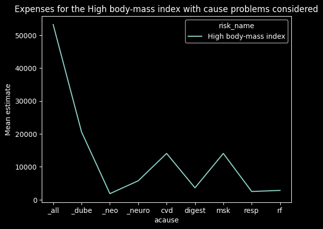

```python
df[(df['risk_name'] == 'High body-mass index') &
  (df['sex'] == 'Female')].pivot_table(values='mean', index='acause', columns='risk_name', aggfunc='mean',
                                          fill_value=None, margins=False, dropna=True).plot(kind = 'line')

plt.ylabel('Mean estimate')
plt.title('Expenses for the High body-mass index with cause problems considered')
```

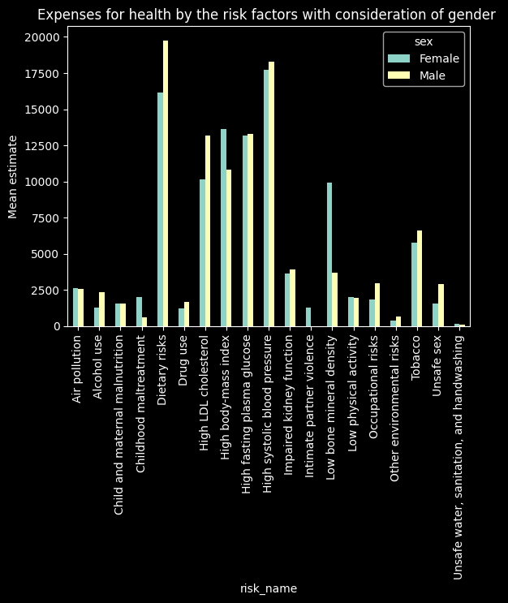

```python
df_bar = df[df['sex'].isin(['Male','Female'])].pivot_table(values='mean',
                index='risk_name', columns='sex', aggfunc='mean',
                      fill_value=None, margins=False, dropna=True)
df_bar.plot(kind = 'bar')
plt.ylabel('Mean estimate')
plt.title('Expenses for health by the risk factors with consideration of gender ')
```

Przedstawić sposoby łączenia ramek danych za pomocą metod merge i concat

```python
df1=df[df["cause_name"] == "Cardiovascular diseases"]
df1.reset_index(drop=True, inplace=True)
df2=df[df["cause_name"] == "Communicable diseases"]
df2.reset_index(drop=True, inplace=True)

df_all = pd.merge(df1, df2, on = ['location_id','location_name', 'year', 'sex_id', 'sex', 'age_group_id', 'age_group_name', 'risk_id','risk_name', 'metric'], how = 'inner')
df_all
```

|  | location_id | location_name | year | sex_id | sex | age_group_id | age_group_name | acause_x | cause_name_x | risk_id | risk_name | metric | mean_x | lower_x | upper_x | acause_y | cause_name_y | mean_y | lower_y | upper_y |
| --- | --- | --- | --- | --- | --- | --- | --- | --- | --- | --- | --- | --- | --- | --- | --- | --- | --- | --- | --- | --- |
| 0 | 102 | United States of America | 2016 | 1 | Male | 170 | 20 to 44 | cvd | Cardiovascular diseases | 85 | Air pollution | 2016 US Dollar | 473.798669 | 318.617149 | 650.439838 | _comm | Communicable diseases | 109.959142 | 31.342214 | 248.191595 |
| 1 | 102 | United States of America | 2016 | 1 | Male | 171 | 45 to 64 | cvd | Cardiovascular diseases | 85 | Air pollution | 2016 US Dollar | 3222.431737 | 2260.697879 | 4255.699005 | _comm | Communicable diseases | 227.351260 | 65.592597 | 533.193269 |
| 2 | 102 | United States of America | 2016 | 1 | Male | 154 | 65 plus | cvd | Cardiovascular diseases | 85 | Air pollution | 2016 US Dollar | 3175.664499 | 2320.878166 | 4096.983159 | _comm | Communicable diseases | 308.090636 | 87.694294 | 693.049383 |
| 3 | 102 | United States of America | 2016 | 1 | Male | 22 | All Ages | cvd | Cardiovascular diseases | 85 | Air pollution | 2016 US Dollar | 6871.894905 | 5321.259657 | 8522.068488 | _comm | Communicable diseases | 813.024551 | 234.484959 | 1848.924601 |
| 4 | 102 | United States of America | 2016 | 2 | Female | 170 | 20 to 44 | cvd | Cardiovascular diseases | 85 | Air pollution | 2016 US Dollar | 336.206406 | 226.769016 | 466.223852 | _comm | Communicable diseases | 144.520409 | 42.323314 | 335.416274 |
| ... | ... | ... | ... | ... | ... | ... | ... | ... | ... | ... | ... | ... | ... | ... | ... | ... | ... | ... | ... | ... |
| 61 | 102 | United States of America | 2016 | 2 | Female | 22 | All Ages | cvd | Cardiovascular diseases | 105 | High fasting plasma glucose | 2016 US Dollar | 17356.562490 | 12558.011720 | 24229.585520 | _comm | Communicable diseases | 11.802825 | 6.876352 | 18.507725 |
| 62 | 102 | United States of America | 2016 | 3 | Both | 170 | 20 to 44 | cvd | Cardiovascular diseases | 105 | High fasting plasma glucose | 2016 US Dollar | 822.220411 | 491.858118 | 1255.013870 | _comm | Communicable diseases | 5.343519 | 2.975340 | 8.124522 |
| 63 | 102 | United States of America | 2016 | 3 | Both | 171 | 45 to 64 | cvd | Cardiovascular diseases | 105 | High fasting plasma glucose | 2016 US Dollar | 12693.238330 | 8782.598600 | 17067.712170 | _comm | Communicable diseases | 18.415471 | 11.168326 | 29.279246 |
| 64 | 102 | United States of America | 2016 | 3 | Both | 154 | 65 plus | cvd | Cardiovascular diseases | 105 | High fasting plasma glucose | 2016 US Dollar | 27129.317460 | 18263.171530 | 39461.811800 | _comm | Communicable diseases | 15.579534 | 6.471645 | 27.067842 |
| 65 | 102 | United States of America | 2016 | 3 | Both | 22 | All Ages | cvd | Cardiovascular diseases | 105 | High fasting plasma glucose | 2016 US Dollar | 40644.776200 | 29596.117700 | 55748.996640 | _comm | Communicable diseases | 39.338524 | 23.915611 | 59.723610 |

66 rows × 20 columns

```python
df_all_new = pd.concat([df1, df2], axis = 0)
df_all_new
```

|  | location_id | location_name | year | sex_id | sex | age_group_id | age_group_name | acause | cause_name | risk_id | risk_name | metric | mean | lower | upper |
| --- | --- | --- | --- | --- | --- | --- | --- | --- | --- | --- | --- | --- | --- | --- | --- |
| 0 | 102 | United States of America | 2016 | 1 | Male | 170 | 20 to 44 | cvd | Cardiovascular diseases | 85 | Air pollution | 2016 US Dollar | 473.798669 | 318.617149 | 650.439838 |
| 1 | 102 | United States of America | 2016 | 1 | Male | 171 | 45 to 64 | cvd | Cardiovascular diseases | 85 | Air pollution | 2016 US Dollar | 3222.431737 | 2260.697879 | 4255.699005 |
| 2 | 102 | United States of America | 2016 | 1 | Male | 154 | 65 plus | cvd | Cardiovascular diseases | 85 | Air pollution | 2016 US Dollar | 3175.664499 | 2320.878166 | 4096.983159 |
| 3 | 102 | United States of America | 2016 | 1 | Male | 22 | All Ages | cvd | Cardiovascular diseases | 85 | Air pollution | 2016 US Dollar | 6871.894905 | 5321.259657 | 8522.068488 |
| 4 | 102 | United States of America | 2016 | 2 | Female | 170 | 20 to 44 | cvd | Cardiovascular diseases | 85 | Air pollution | 2016 US Dollar | 336.206406 | 226.769016 | 466.223852 |
| ... | ... | ... | ... | ... | ... | ... | ... | ... | ... | ... | ... | ... | ... | ... | ... |
| 122 | 102 | United States of America | 2016 | 3 | Both | 158 | <20 years | _comm | Communicable diseases | 170 | Unsafe sex | 2016 US Dollar | 792.848141 | 678.780891 | 947.804713 |
| 123 | 102 | United States of America | 2016 | 3 | Both | 170 | 20 to 44 | _comm | Communicable diseases | 170 | Unsafe sex | 2016 US Dollar | 4228.575383 | 3344.415760 | 5338.997314 |
| 124 | 102 | United States of America | 2016 | 3 | Both | 171 | 45 to 64 | _comm | Communicable diseases | 170 | Unsafe sex | 2016 US Dollar | 5894.381121 | 3330.656633 | 8648.772046 |
| 125 | 102 | United States of America | 2016 | 3 | Both | 154 | 65 plus | _comm | Communicable diseases | 170 | Unsafe sex | 2016 US Dollar | 1414.580810 | 1231.341521 | 1599.422248 |
| 126 | 102 | United States of America | 2016 | 3 | Both | 22 | All Ages | _comm | Communicable diseases | 170 | Unsafe sex | 2016 US Dollar | 12330.385460 | 8748.120465 | 16188.038220 |

295 rows × 15 columns

Pokazać dodawanie nowych kolumn za pomocą operacji matematycznych

```python
df["mean_round"] = df["mean"].round(decimals = 2)
df["mean_total"] = df["mean"]+df["lower"]+df["upper"]
df["tmean_med"] = df.loc[:, "mean":"upper"].median(axis = 1)
df
```

|  | location_id | location_name | year | sex_id | sex | age_group_id | age_group_name | acause | cause_name | risk_id | risk_name | metric | mean | lower | upper | mean_round | mean_total | tmean_med |
| --- | --- | --- | --- | --- | --- | --- | --- | --- | --- | --- | --- | --- | --- | --- | --- | --- | --- | --- |
| 0 | 102 | United States of America | 2016 | 1 | Male | 158 | <20 years | _all | All causes | 82 | Unsafe water, sanitation, and handwashing | 2016 US Dollar | 52.810750 | 34.776353 | 76.466271 | 52.81 | 164.053374 | 52.810750 |
| 1 | 102 | United States of America | 2016 | 1 | Male | 170 | 20 to 44 | _all | All causes | 82 | Unsafe water, sanitation, and handwashing | 2016 US Dollar | 48.000244 | 31.644490 | 70.893323 | 48.00 | 150.538057 | 48.000244 |
| 2 | 102 | United States of America | 2016 | 1 | Male | 171 | 45 to 64 | _all | All causes | 82 | Unsafe water, sanitation, and handwashing | 2016 US Dollar | 69.765933 | 45.764417 | 101.797946 | 69.77 | 217.328296 | 69.765933 |
| 3 | 102 | United States of America | 2016 | 1 | Male | 154 | 65 plus | _all | All causes | 82 | Unsafe water, sanitation, and handwashing | 2016 US Dollar | 88.960404 | 59.168652 | 128.091201 | 88.96 | 276.220257 | 88.960404 |
| 4 | 102 | United States of America | 2016 | 1 | Male | 22 | All Ages | _all | All causes | 82 | Unsafe water, sanitation, and handwashing | 2016 US Dollar | 259.537331 | 171.226033 | 375.015989 | 259.54 | 805.779353 | 259.537331 |
| ... | ... | ... | ... | ... | ... | ... | ... | ... | ... | ... | ... | ... | ... | ... | ... | ... | ... | ... |
| 1236 | 102 | United States of America | 2016 | 3 | Both | 158 | <20 years | rf | Expenditure on risk factors | 108 | High body-mass index | 2016 US Dollar | 186.043387 | 142.143526 | 232.865620 | 186.04 | 561.052532 | 186.043387 |
| 1237 | 102 | United States of America | 2016 | 3 | Both | 170 | 20 to 44 | rf | Expenditure on risk factors | 108 | High body-mass index | 2016 US Dollar | 3697.662630 | 2626.047083 | 4824.208117 | 3697.66 | 11147.917830 | 3697.662630 |
| 1238 | 102 | United States of America | 2016 | 3 | Both | 171 | 45 to 64 | rf | Expenditure on risk factors | 108 | High body-mass index | 2016 US Dollar | 4403.916422 | 3083.734761 | 5662.947080 | 4403.92 | 13150.598263 | 4403.916422 |
| 1239 | 102 | United States of America | 2016 | 3 | Both | 154 | 65 plus | rf | Expenditure on risk factors | 108 | High body-mass index | 2016 US Dollar | 1457.018966 | 1104.520225 | 2292.252672 | 1457.02 | 4853.791863 | 1457.018966 |
| 1240 | 102 | United States of America | 2016 | 3 | Both | 22 | All Ages | rf | Expenditure on risk factors | 108 | High body-mass index | 2016 US Dollar | 9744.641404 | 7222.418431 | 12418.772000 | 9744.64 | 29385.831835 | 9744.641404 |

1241 rows × 18 columns

Przedstawić na przykładzie dodawanie nowych kolumn z pomocą funkcji lambda

```python
youngest = ['20 to 44', '<20 years', '20 to 32', '32 to 44']
df['youngest'] = df['age_group_name'].apply(lambda x: True if x in youngest else False )
df[df['youngest'] == True]
```

|  | location_id | location_name | year | sex_id | sex | age_group_id | age_group_name | acause | cause_name | risk_id | risk_name | metric | mean | lower | upper | mean_round | mean_total | tmean_med | youngest |
| --- | --- | --- | --- | --- | --- | --- | --- | --- | --- | --- | --- | --- | --- | --- | --- | --- | --- | --- | --- |
| 0 | 102 | United States of America | 2016 | 1 | Male | 158 | <20 years | _all | All causes | 82 | Unsafe water, sanitation, and handwashing | 2016 US Dollar | 52.810750 | 34.776353 | 76.466271 | 52.81 | 164.053374 | 52.810750 | True |
| 1 | 102 | United States of America | 2016 | 1 | Male | 170 | 20 to 44 | _all | All causes | 82 | Unsafe water, sanitation, and handwashing | 2016 US Dollar | 48.000244 | 31.644490 | 70.893323 | 48.00 | 150.538057 | 48.000244 | True |
| 5 | 102 | United States of America | 2016 | 2 | Female | 158 | <20 years | _all | All causes | 82 | Unsafe water, sanitation, and handwashing | 2016 US Dollar | 50.183598 | 33.315353 | 74.363904 | 50.18 | 157.862856 | 50.183598 | True |
| 6 | 102 | United States of America | 2016 | 2 | Female | 170 | 20 to 44 | _all | All causes | 82 | Unsafe water, sanitation, and handwashing | 2016 US Dollar | 68.050031 | 44.128452 | 100.984476 | 68.05 | 213.162959 | 68.050031 | True |
| 10 | 102 | United States of America | 2016 | 3 | Both | 158 | <20 years | _all | All causes | 82 | Unsafe water, sanitation, and handwashing | 2016 US Dollar | 102.994348 | 68.226080 | 150.584100 | 102.99 | 321.804528 | 102.994348 | True |
| ... | ... | ... | ... | ... | ... | ... | ... | ... | ... | ... | ... | ... | ... | ... | ... | ... | ... | ... | ... |
| 1227 | 102 | United States of America | 2016 | 1 | Male | 170 | 20 to 44 | rf | Expenditure on risk factors | 108 | High body-mass index | 2016 US Dollar | 829.830985 | 596.954019 | 1097.459401 | 829.83 | 2524.244404 | 829.830985 | True |
| 1231 | 102 | United States of America | 2016 | 2 | Female | 158 | <20 years | rf | Expenditure on risk factors | 108 | High body-mass index | 2016 US Dollar | 101.248712 | 80.521641 | 126.900237 | 101.25 | 308.670590 | 101.248712 | True |
| 1232 | 102 | United States of America | 2016 | 2 | Female | 170 | 20 to 44 | rf | Expenditure on risk factors | 108 | High body-mass index | 2016 US Dollar | 2867.831645 | 2015.340713 | 3745.282634 | 2867.83 | 8628.454992 | 2867.831645 | True |
| 1236 | 102 | United States of America | 2016 | 3 | Both | 158 | <20 years | rf | Expenditure on risk factors | 108 | High body-mass index | 2016 US Dollar | 186.043387 | 142.143526 | 232.865620 | 186.04 | 561.052532 | 186.043387 | True |
| 1237 | 102 | United States of America | 2016 | 3 | Both | 170 | 20 to 44 | rf | Expenditure on risk factors | 108 | High body-mass index | 2016 US Dollar | 3697.662630 | 2626.047083 | 4824.208117 | 3697.66 | 11147.917830 | 3697.662630 | True |

428 rows × 19 columns

Przedstawić możliwości pracy z dużymi plikami przy użyciu argumentu chunksize

```python
for chunk_df in pd.read_csv(r"/Users/annamazur/Desktop/studia/nod/laborki/Lab1/IHME_USA_RISK_SPENDING_2016_Y2020M09D29.CSV",
                      chunksize = 500):
    print("CHUNK DF")
    print(chunk_df.head())
```

```
CHUNK DF
   location_id             location_name  year  sex_id   sex  age_group_id  \
0          102  United States of America  2016       1  Male           158
1          102  United States of America  2016       1  Male           170
2          102  United States of America  2016       1  Male           171
3          102  United States of America  2016       1  Male           154
4          102  United States of America  2016       1  Male            22

  age_group_name acause  cause_name  risk_id  \
0      <20 years   _all  All causes       82
1       20 to 44   _all  All causes       82
2       45 to 64   _all  All causes       82
3        65 plus   _all  All causes       82
4       All Ages   _all  All causes       82

```

[output cut: 76 more lines]

```python
new_df = pd.DataFrame()
for chunk_df in pd.read_csv(r"/Users/annamazur/Desktop/studia/nod/laborki/Lab1/IHME_USA_RISK_SPENDING_2016_Y2020M09D29.CSV",
                      chunksize = 500):
    result = chunk_df.groupby(['cause_name', 'sex']).agg({'mean': 'mean',
                                                    'upper': 'mean'})
    new_df = pd.concat([new_df,result])
new_df
```

| cause_name | sex | mean | upper |
| --- | --- | --- | --- |
| All causes | Both | 25487.862184 | 30043.617374 |
|  | Female | 12526.761595 | 15025.278885 |
|  | Male | 13714.652950 | 16309.052134 |
| Communicable diseases | Both | 1287.447489 | 1984.636777 |
|  | Female | 610.436058 | 977.135810 |
|  | Male | 763.807768 | 1175.091958 |
| Diabetes and urogenital, blood, and endocrine diseases | Both | 16475.119053 | 19406.986426 |
|  | Female | 8638.558098 | 10388.402998 |
|  | Male | 8093.603447 | 9889.275320 |
| Cardiovascular diseases | Both | 12890.344535 | 15998.512304 |
|  | Female | 6734.292052 | 8509.557192 |
|  | Male | 8293.260539 | 10760.617384 |
| Cirrhosis | Both | 3244.105959 | 4158.633516 |
|  | Female | 1496.960760 | 1957.734434 |
|  | Male | 1747.145199 | 2256.327924 |
| Diabetes and urogenital, blood, and endocrine diseases | Both | 4962.813934 | 6395.956472 |
|  | Female | 2319.312322 | 3020.632798 |
|  | Male | 2643.501612 | 3403.378702 |
| Injuries | Both | 4176.353581 | 5382.025012 |
|  | Female | 2211.215196 | 2881.059047 |
|  | Male | 2392.342382 | 3175.228587 |
| Mental and substance use disorders | Both | 2388.890516 | 2968.019267 |
|  | Female | 1298.342599 | 1726.568399 |
|  | Male | 1363.184896 | 1692.041102 |
| Neoplasms | Both | 1446.232648 | 1915.289780 |
|  | Female | 632.063739 | 861.060833 |
|  | Male | 906.688104 | 1204.599695 |
| Neurological disorders | Both | 4259.584483 | 7568.752053 |
|  | Female | 2707.917577 | 5169.603031 |
|  | Male | 1551.666907 | 2845.842932 |
| Cardiovascular diseases | Both | 18268.203355 | 22248.236271 |
|  | Female | 7007.985549 | 8572.021292 |
|  | Male | 8830.313748 | 10520.115156 |
| Chronic respiratory diseases | Both | 3671.301678 | 4746.334950 |
|  | Female | 2111.878365 | 2793.777028 |
|  | Male | 1559.423313 | 2039.330101 |
| Digestive diseases | Both | 2060.161661 | 2787.444718 |
|  | Female | 1310.505714 | 1759.936769 |
|  | Male | 749.655947 | 1103.302115 |
| Expenditure on risk factors | Both | 17744.569972 | 20091.828314 |
|  | Female | 9720.645114 | 11542.729427 |
|  | Male | 8023.924858 | 9525.322164 |
| Musculoskeletal disorders | Both | 10968.024906 | 14144.772425 |
|  | Female | 6050.112426 | 8181.742770 |
|  | Male | 4917.912480 | 6388.179497 |